# HETH_processing_6-5-2021

Nicole Adams

6/5/2021

# Sequence processesing for HETH samples

We split all samples 236 into two libraries and sequenced each library on a separate lane of NovaSeq. Library HETH_005 had 118 samples and library HETH_006 had 118 samples. The sequencing resulted in 476 files, which included forward and reverse files for each sample plus forward and reverse files for reads that could not be demultiplexed and were labeled “Undetermined”.

Load in libraries

```r
library(readxl)
library(data.table)
library(tidyverse)
library(viridis)
library(cowplot)
library(ggpubr)
library(knitr)
library(kableExtra)
```

# Load in metadata and tidy

```r
# sample metadata
meta1a <- read_excel("~/Documents/clim_morph_HETH/HETH_WGLC_005&006_libprep.xlsx", sheet = "Lib Prep")
meta1a$Sample_og <- meta1a$Sample
meta1a$Sample1 <- "Z"
meta1 <- meta1a %>% unite("Sample", Sample1:Sample_og, sep = "")

# sample seq data for Novogene
meta2 <- read_excel("~/Documents/clim_morph_HETH/HETH_SIFLIB.xlsx")
colnames(meta2) <- c("LibraryType", "Library", "Sample", "DataDelivery", "index_i7", "index_i5", "insertSz", "Status", "totalData", "dataUnit", "conc", "volume")
meta2 <- meta2 %>% select(Sample, Library, index_i7, index_i5, insertSz, conc, volume)
meta12 <- full_join(meta1, meta2)

# raw seq results from Novogene
meta3 <- read_tsv("~/Documents/clim_morph_HETH/HETH_qc.summary_final.txt")
meta3 <- meta3 %>% filter(!Sample =="Undetermined")

# combine Novogene data
heth.meta1 <- full_join(meta12, meta3) # by=c("Sample")
```

summary statistics on raw reads

```r
# Number of raw reads across all samples (in billions)
sum(meta3$`Raw reads`)/1000000000  #12.4
```

```
## [1] 12.43499
```

```r
# % of samples having 89% or more of reads with a quality score of Q>30
(dim(meta3 %>% filter(`Q30(%)` > 89))[1]/dim(meta3)[1])*100  #91%
```

```
## [1] 90.67797
```

# Download raw sequence data from Novogene

Bash commands for getting raw data from Novogene to Xsede etc.

```bash
# For HETH Novogene -> Xsede
mkdir /ocean/projects/deb200006p/adamsne2/HETH/raw_data

# Run novogene2xsede.sbatch
cd /ocean/projects/deb200006p/adamsne2/HETH/raw_data/
wget -r -c ftp://X202SC21043579-Z01-F001:8e7g46xe@usftp21.novogene.com:21/

# For HETH Novogene -> BAY_BIRDS external HD, via my mac
mkdir /Volumes/BAY_BIRDS/HETH/raw_data
cd raw_data
/usr/local/opt/wget/bin/wget -r -c ftp://X202SC21043579-Z01-F001:8e7g46xe@usftp21.novogene.com:21/


# Organize files
# HETH: Copy fastq files from individual folders up a lvl to raw_data directory for easy access (~/scripts/mvUpRawFastq.sbatch)
cp /ocean/projects/deb200006p/adamsne2/HETH/raw_data/usftp21.novogene.com/raw_data/*/*.gz /ocean/projects/deb200006p/adamsne2/HETH/raw_data/usftp21.novogene.com/raw_data

# rm fq files in indiv folders but kept the MD5.txt files
rm */*.fq.gz
```

## Trimming

Remove any adapters and trim raw reads based on read length and quality using Trim Galore!

Trimming sbatch file (~/scripts/trimgalore_HETH.sbatch)

```bash
#!/bin/bash
#SBATCH --job-name=TRIM
#SBATCH --output=TRIM.%j.out
#SBATCH --error=TRIM.%j.err
#SBATCH -t 48:00:00
#SBATCH -p RM-shared
##SBATCH -N 1
##SBATCH --mem=128G
#SBATCH -A
#SBATCH --mail-type=END
#SBATCH --mail-user=

set -x

module load FastQC/0.11.9
module load cutadapt/2.10
module load python/3.8.6

###Identify directories
fastq="/ocean/projects/deb200006p/adamsne2/HETH/raw_data/usftp21.novogene.com/raw_data"
num=$2
sample=$1

#Note: Take a look at the names of the sample files and adjust this loop accordingly
#For example, mine all had "CKDL190142674-1a-AK12626-AK16295_H3VF5CCX2_L8_2.fq.gz" or "USPD16094205-N707-AK392_HY5K5CCXY_L7_2.fq.gz" tacked on.

### Trim low quality fragments and Illumina TruSeq adapters (-q = quality, --cores 1-4 python3 uses 2)
mkdir ../trimd
cd ../trimd

# leave adapters blank so uses the auto-detect
/jet/home/adamsne2/programs/TrimGalore-0.6.5/trim_galore -q 15 --paired --fastqc \
$fastq/$sample\_L3_1.fq.gz $fastq/$sample\_L3_2.fq.gz
```

Test one sample

```bash
for sample in `ls Z341567_CKDL210010184-1a-AK1858-N505_HC2JNDSX2_L3_1.fq.gz | cut -f1,2,3 -d '_'`; do echo $sample; sbatch ~/scripts/trimgalore_HETH.sbatch $sample; done
```

Pull down the new fastqc html file made after trimming to look at

```bash
scp adamsne2@bridges2.psc.xsede.org:"/ocean/projects/deb200006p/adamsne2/HETH/raw_data/usftp21.novogene.com/trimd/*.html" .
```

Trim all samples by lane (L3=HETH_005, L4=HETH_006)

```bash
for sample in `ls *_L3_1.fq.gz | cut -f1,2,3 -d '_'`; do echo $sample; sbatch ~/scripts/trimgalore_HETH.sbatch $sample; done

for sample in `ls *_L4_1.fq.gz | cut -f1,2,3 -d '_'`; do echo $sample; sbatch ~/scripts/trimgalore_HETH2.sbatch $sample; done
```

## Mapping

Download the Swainson’s Thrush (Catharus ustulatus, SWTH) genome to Bridges2 [SWTH genome](https://www.ncbi.nlm.nih.gov/genome/?term=Swainson%27s+Thrush)

```bash
cd /ocean/projects/deb200006p/adamsne2/HETH/reference

wget https://ftp.ncbi.nlm.nih.gov/genomes/all/GCF/009/819/885/GCF_009819885.2_bCatUst1.pri.v2/GCF_009819885.2_bCatUst1.pri.v2_genomic.fna.gz
```

### Index the reference genome and make a directory

(~/scripts/indexReference_SWTH.sbatch)

```bash
#!/bin/bash
#SBATCH --job-name=REF.INDEX
#SBATCH --output=REF.INDEX_%j_out
#SBATCH --error=REF.INDEX_%j_err
#SBATCH -t 12:00:00
#SBATCH -p RM
##SBATCH -N 1
##SBATCH --ntasks-per-node 4
##SBATCH --mem=16G
#SBATCH -A
#SBATCH --mail-type=END
#SBATCH --mail-user=

set -x

module load BWA/0.7.3a
module load samtools/1.11.0
module load picard/2.23.2

cd /ocean/projects/deb200006p/adamsne2/HETH/reference/

gunzip GCF_009819885.2_bCatUst1.pri.v2_genomic.fna.gz

bwa index -a bwtsw GCF_009819885.2_bCatUst1.pri.v2_genomic.fna

samtools faidx GCF_009819885.2_bCatUst1.pri.v2_genomic.fna

java -jar /jet/home/adamsne2/programs/picard.jar CreateSequenceDictionary R=GCF_009819885.2_bCatUst1.pri.v2_genomic.fna O=GCF_009819885.2_bCatUst1.pri.v2_genomic.fna.dict

gzip GCF_009819885.2_bCatUst1.pri.v2_genomic.fna
```

Mapping sbatch file (~/scripts/map.bwa_HETH_SWTH.sbatch) I had to include the bwa -M parameter to flag shorter split hits as secondary to make the resulting bam files compatible with PicardTools, which I use for markDuplicates and coverage estimates.

```bash
#!/bin/bash
#SBATCH --job-name=map_bwa
#SBATCH --output=map-bwa.%j.out
#SBATCH --error=map-bwa.%j.err
#SBATCH -t 12:00:00
#SBATCH -p RM
##SBATCH -N 1
##SBATCH --ntasks-per-node 24
##SBATCH --mem=128G
#SBATCH -A
#SBATCH --mail-type=END
#SBATCH --mail-user=

set -x


module load BWA/0.7.3a
module load samtools/1.11.0
module load picard/2.23.2

##Variables: Plate number and directory for bamUtil
PLATE="HETH_005"
BAMUTIL="/jet/home/adamsne2/programs/bamUtil/bin"
#REFERENCE="/ocean/projects/deb200006p/adamsne2/HETH/reference/HETH.rmcont.assembly.fasta"
REFERENCE="/ocean/projects/deb200006p/adamsne2/HETH/reference/GCF_009819885.2_bCatUst1.pri.v2_genomic.fna"

lane=$2
sample=$1
sample2=$3


cd /ocean/projects/deb200006p/adamsne2/HETH/raw_data/usftp21.novogene.com/trimd/

##Align each sample to genome. Note that genome reference must already be built through bwa
#mkdir ../../../bwa_map

ID="$PLATE.$sample2.$lane"

##map trimmed reads BY lane
bwa mem -t 20 -M $REFERENCE "$sample"_1_val_1.fq.gz "$sample"_2_val_2.fq.gz > /ocean/projects/deb200006p/adamsne2/HETH/bwa_map/toSWTH/"$sample2".sw.sam

cd /ocean/projects/deb200006p/adamsne2/HETH/bwa_map/toSWTH

#########sort, add read group information and index it#########
samtools sort -o "$sample2".sw.bam "$sample2".sw.sam -@ 10
samtools index "$sample2".sw.bam -@10

##Add read groups (dont do this for HETH)
#java -jar /jet/home/adamsne2/programs/picard.jar AddOrReplaceReadGroups INPUT=aln_"$sample2".bam RGID="$ID" RGLB="$PLATE" RGPL=illumina RGPU="$PLATE"."$sample2"."lane" RGSM="$sample2" OUTPUT="$sample2"_RG.bam VALIDATION_STRINGENCY=SILENT

#samtools index "$sample2"_RG.bam -@10


rm "$sample2".sw.sam
```

Map loop for a small set of samples to see how well they do

```bash
#/ocean/projects/deb200006p/adamsne2/HETH/raw_data/usftp21.novogene.com/trimd

# test a small set of samples to see how well they do n=24
for sample in `ls Z43*L3_1_val_1.fq.gz | cut -f1,2,3,4 -d'_'`; do lane=`ls $sample\_1_val_1.fq.gz | cut -f4 -d"_"`; sample2=`ls $sample\_1_val_1.fq.gz | cut -f1 -d'_'`; echo $sample; echo $lane;echo $sample2; sbatch ~/scripts/map.bwa_HETH_SWTH.sbatch $sample $lane $sample2; done

# Map the remaining samples in L3
for sample in `ls *L3_1_val_1.fq.gz | grep -v "Z43" | cut -f1,2,3,4 -d'_'`; do lane=`ls $sample\_1_val_1.fq.gz | cut -f4 -d"_"`; sample2=`ls $sample\_1_val_1.fq.gz | cut -f1 -d'_'`; echo $sample; echo $lane;echo $sample2; sbatch ~/scripts/map.bwa_HETH_SWTH.sbatch $sample $lane $sample2; done

# Map L4 *Change the PLATE to HETH_006
for sample in `ls *L4_1_val_1.fq.gz | cut -f1,2,3,4 -d'_'`; do lane=`ls $sample\_1_val_1.fq.gz | cut -f4 -d"_"`; sample2=`ls $sample\_1_val_1.fq.gz | cut -f1 -d'_'`; echo $sample; echo $lane;echo $sample2; sbatch ~/scripts/map.bwa_HETH_SWTH.sbatch $sample $lane $sample2; done
```

Mapping summaries Bash commands for samtools flagstat to get mapping summaries. Then take the results and make a table and put in one file to be put into Rstudio. batch file (~/scripts/sam.flagstat_HETH_SWTH.sbatch)

```bash
#!/bin/bash
#SBATCH --job-name=map_sum
#SBATCH --output=map-sum.%j.out
#SBATCH --error=map-sum.%j.err
#SBATCH -t 10:00:00
#SBATCH -p RM
##SBATCH -N 1
##SBATCH --ntasks-per-node 24
##SBATCH --mem=128G
#SBATCH -A
#SBATCH --mail-type=END
#SBATCH --mail-user=

set -x


module load samtools/1.11.0

#cd /ocean/projects/deb200006p/adamsne2/HETH/bwa_map/toSWTH

touch mapSummary_HETH_SWTH.txt

for sample in `ls *.bam | cut -f1 -d'.'`
do
  samtools flagstat "$sample".sw.bam -@ 10  > "$sample"_sw.mapSum.txt
 awk 'FNR == 1{ print FILENAME }' "$sample"_sw.mapSum.txt >> mapSummary_HETH_SWTH.txt
 cat "$sample"_sw.mapSum.txt >> mapSummary_HETH_SWTH.txt

done

for sample in *mapSum.txt; do awk 'FNR == 1{ print FILENAME } {printf "%-20s %-40s\n", $1, $3}' OFS="\t" $sample | awk '
{
    for (i=1; i<=NF; i++)  {
        a[NR,i] = $i
    }
}
NF>p { p = NF }
END {
    for(j=1; j<=p; j++) {
        str=a[1,j]
        for(i=2; i<=NR; i++){
            str=str" "a[i,j];
        }
        print str
    }
}' >> mapSummary_HETH_SWTH.2.txt; done

grep 'Z' mapSummary_HETH_SWTH.2.txt > mapSummary_HETH_SWTH.3.txt

rm *_sw.mapSum.txt
```

scp map summary file to computer and put into Rstudio

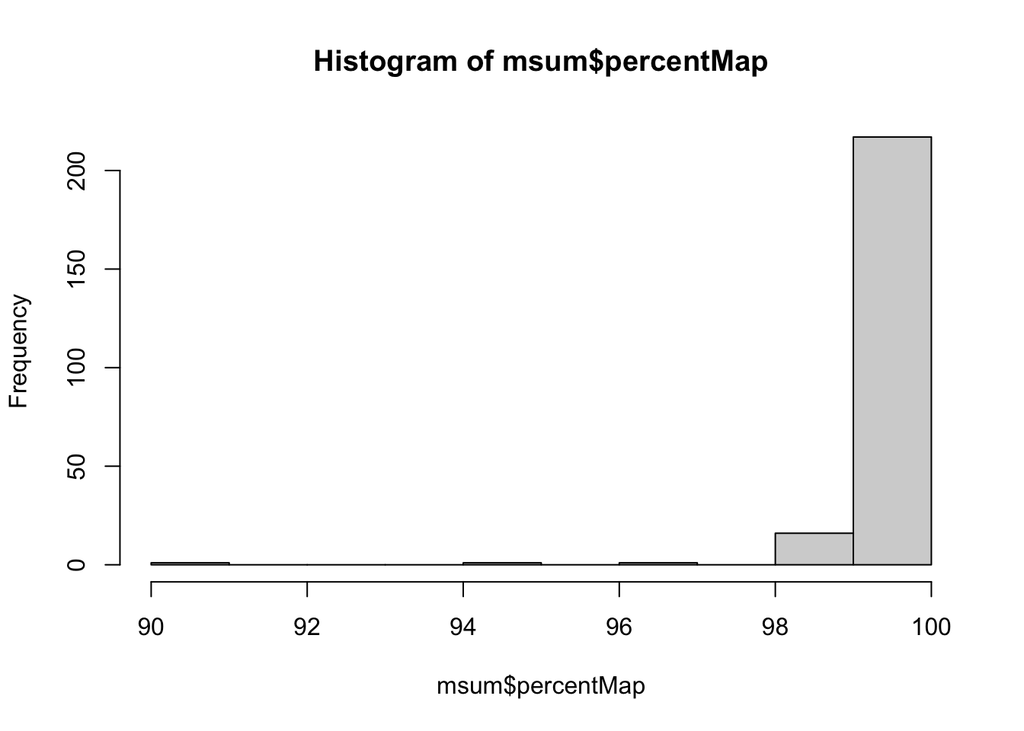

```r
msum <- read.table("~/Documents/clim_morph_HETH/mapSummary_HETH_SWTH.3.txt")

colnames(msum) <- c("Sample", "QCpassedReads", "secondary", "supplementary", "duplicates", "mapped", "paired", "read1", "read2", "properlyPaired", "itselfYmateMapped", "singletons", "mateMappedDiffChr", "mateMappedDiffChr_mapQ5")

msum <- msum %>% separate(Sample, c("Sample", "rg", "stuff", "file")) %>% dplyr::select(-rg, -stuff, -file) %>% distinct(Sample, .keep_all = TRUE) # need to remove duplicate samples in the file bc they were run twice and appended

msum$percentMap <- (msum$mapped/msum$QCpassedReads)*100
msum$percentPaired <- (msum$properlyPaired/msum$paired)*100
msum$percentSingle <- (msum$singletons/msum$properlyPaired)*100

# merge mapping summary with meta data
#heth.meta2 <- inner_join(heth.meta1, msum)

hist(msum$percentMap)
```

```r
msum %>% summarise(mean=mean(percentMap), sd=sd(percentMap))
```

```
##       mean        sd
## 1 99.22202 0.7156679
```

```r
# merge mapping summary with meta data
heth.meta2 <- inner_join(heth.meta1, msum)
```

## Mark duplicates

sbatch file (~/scripts/markdups_HETH_SWTH.sbatch)

```bash
#!/bin/bash
#SBATCH --job-name=mrkdup
#SBATCH --output=mrkdup.%j.out
#SBATCH --error=mrkdup.%j.err
#SBATCH -t 48:00:00
#SBATCH -p EM
#number of nodes- for RM-shared -N 1
#SBATCH -N 1
#SBATCH --ntasks-per-node 24
##SBATCH --mem=128G
#SBATCH -A
#SBATCH --mail-type=END
#SBATCH --mail-user=

set -x

sample=$1
sample2=$2

module load samtools/1.11.0
module load GATK/4.1.9.0

cd /ocean/projects/deb200006p/adamsne2/HETH/bwa_map/toSWTH

java -jar /jet/home/adamsne2/programs/picard.jar MarkDuplicates \
      I="$sample" \
      O="$sample2".sw.mrkdup.bam \
      M="$sample2".sw.mrkdup_metrics.txt

samtools index "$sample2".sw.mrkdup.bam
```

loop to mark duplicates

```bash
for sample in `ls *.bam`; do sample2=`ls $sample | cut -f1 -d'.'| cut -f1 -d"_"`; echo $sample; echo $sample2; sbatch ~/scripts/markdups_HETH_SWTH.sbatch $sample $sample2; done
```

Combine markdup metrics Bash code to combine markdup metric summaries.

```bash
touch toSWTH_mrkdup_metrics.txt

for sample in *.sw.mrkdup_metrics.txt; do grep "^Unknown" $sample /dev/null >> toSWTH_mrkdup_metrics.txt; done
```

scp file to laptop

Put combined metric summary into Rstudio

```r
# Data input and wrangling
dups <- as.data.frame(read_tsv("/Users/neasci/Documents/clim_morph_HETH/toSWTH_mrkdup_metrics.txt", col_names = FALSE))

colnames(dups) <- c("LIBRARY", "UNPAIRED_READS_EXAMINED", "READ_PAIRS_EXAMINED", "SECONDARY_OR_SUPPLEMENTARY_RDS", "UNMAPPED_READS", "UNPAIRED_READ_DUPLICATES", "READ_PAIR_DUPLICATES", "READ_PAIR_OPTICAL_DUPLICATES", "PERCENT_DUPLICATION", "ESTIMATED_LIBRARY_SIZE")

 dups <- dups %>% separate(LIBRARY, c("Sample", "stuff1", "stuff2", "stuff3", "file", "library1")) %>% subset(select=-c(stuff1, stuff2, stuff3, file, library1))

 # combine with metadata
 heth.meta3 <- inner_join(dups, heth.meta2)

 p.dups <- ggplot(heth.meta3, aes(x=PERCENT_DUPLICATION, fill=Library)) +
  geom_histogram( alpha=0.5, show.legend = T) +
  scale_fill_viridis_d( option = "cividis") +
  theme_minimal()

 p.dups2 <- ggplot(heth.meta3, aes(x= percentMap, y=PERCENT_DUPLICATION, color=Library)) +
   geom_point() +
   scale_color_viridis_d( option = "cividis") +
  theme_minimal()

dups.yr.p <- ggplot(heth.meta3, aes(x= Year, y=PERCENT_DUPLICATION, color=PERCENT_DUPLICATION)) +
   geom_point(show.legend = FALSE) +
   scale_color_viridis_c( option = "cividis") +
  theme_minimal()

dups %>% summarise(mean=mean(PERCENT_DUPLICATION), sd=sd(PERCENT_DUPLICATION))
```

```
##       mean         sd
## 1 0.316834 0.02610362
```

```r
 p.dups
```

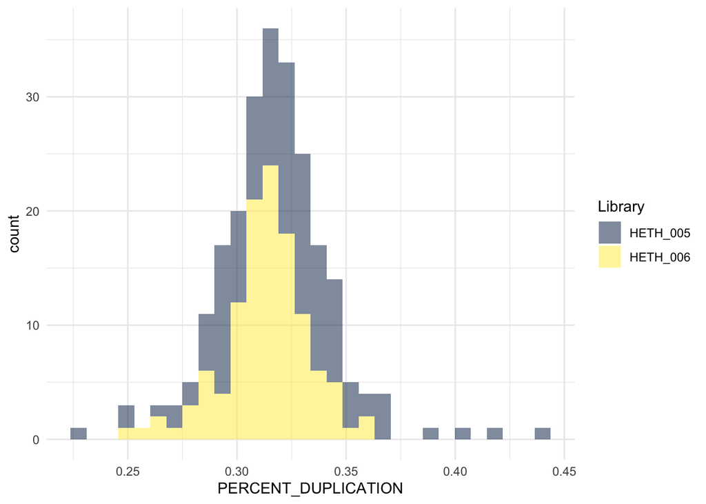

```r
 dups.yr.p
```

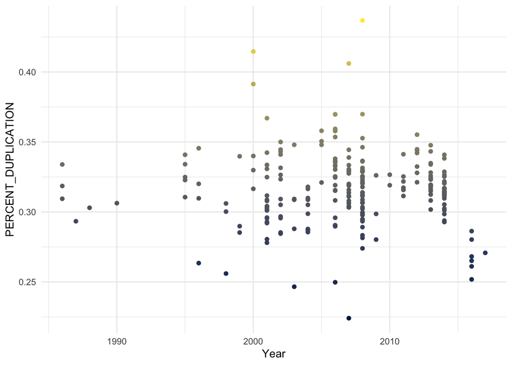

## Estimate depth of coverage with Picard collect wgs

Batch script to calculate coverage using Picard (collectWGSmetrics_HETH_SWTH.sbatch)

```bash
#!/bin/bash
#SBATCH --job-name=wgsMetrics
#SBATCH --output=wgs.%j.out
#SBATCH --error=wgs.%j.err
#SBATCH -t 24:00:00
#SBATCH -p RM
##SBATCH -N 1
##SBATCH --ntasks 24
##SBATCH --mem=120G
#SBATCH -A
#SBATCH --mail-type=END
#SBATCH --mail-user=

module load GATK/4.1.9.0

sample=$1
sample2=$2

#REFERENCE="/ocean/projects/deb200006p/adamsne2/HETH/reference/HETH.rmcont.assembly.fasta"
REFERENCE="/ocean/projects/deb200006p/adamsne2/HETH/reference/GCF_009819885.2_bCatUst1.pri.v2_genomic.fna"

cd /ocean/projects/deb200006p/adamsne2/HETH/bwa_map/toSWTH

java -jar ~/programs/picard.jar CollectWgsMetrics\
      I="$sample" \
      O="$sample2".collectWGSmetrics.sw.txt \
      R=$REFERENCE

#touch HETH_005-6.collectWGSmetrics.txt
#for sample in *collectWGSmetrics.txt; do awk 'FNR == 1 {print FILENAME}  FNR == 8 {print}' $sample >> HETH_005-6.collectWGSmetrics.txt; done
```

loop to get coverage

```bash
for sample in *.sw.mrkdup.bam ; do sample2=`ls $sample | cut -f1 -d'.'| cut -f1 -d'_'`; echo $sample $sample2; sbatch ~/scripts/collectWGSmetrics_HETH_SWTH.sbatch $sample $sample2; done
```

Combine collectWGS metrics Bash code to combine collectWGS metric summaries. code from (here)[https://stackoverflow.com/questions/42941329/how-can-i-print-the-nth-5th-line-of-every-file-preceded-by-the-filename-using]

```bash
touch HETH_SWTH.collectWGSmetrics.txt

for file in *collectWGSmetrics.sw.txt; do echo "$file" $(sed 's/ /,/;s/$/,/;8q;d' "$file") >> HETH_SWTH.collectWGSmetrics.txt; done
```

scp file to laptop

Put combined collect metrics into R

```r
wgs <- read_tsv("/Users/neasci/Documents/clim_morph_HETH/HETH_SWTH.collectWGSmetrics.txt", col_names = FALSE)

# remove first line that says, "*collectWGSmetrics.txt"
wgs <- wgs[-1,]

wgs2 <- wgs %>% separate(X1, c("Sample", "GENOME_TERRITORY", "MEAN_COVERAGE", "SD_COVERAGE", "MEDIAN_COVERAGE", "MAD_COVERAGE", "PCT_EXC_ADAPTER", "PCT_EXC_MAPQ", "PCT_EXC_DUPE", "PCT_EXC_UNPAIRED", "PCT_EXC_BASEQ", "PCT_EXC_OVERLAP", "PCT_EXC_CAPPED", "PCT_EXC_TOTAL", "PCT_1X", "PCT_5X", "PCT_10X", "PCT_15X", "PCT_20X", "PCT_25X", "PCT_30X", "PCT_40X", "PCT_50X", "PCT_60X", "PCT_70X", "PCT_80X", "PCT_90X", "PCT_100X", "HET_SNP_SENSITIVITY", "HET_SNP_Q"), sep = '\\s')

# remove file name and keep sample name
wgs3 <- wgs2 %>% separate(Sample, c("Sample", "stuff1", "stuff2")) %>% dplyr::select(-stuff1, -stuff2)

# merge with meta data
heth.meta4 <- inner_join(wgs3, heth.meta3)

# convert character columns to numeric
cols.num <- c("GENOME_TERRITORY", "MEAN_COVERAGE", "SD_COVERAGE", "MEDIAN_COVERAGE", "MAD_COVERAGE", "PCT_EXC_ADAPTER", "PCT_EXC_MAPQ", "PCT_EXC_DUPE", "PCT_EXC_UNPAIRED", "PCT_EXC_BASEQ", "PCT_EXC_OVERLAP", "PCT_EXC_CAPPED", "PCT_EXC_TOTAL", "PCT_1X", "PCT_5X", "PCT_10X", "PCT_15X", "PCT_20X", "PCT_25X", "PCT_30X", "PCT_40X", "PCT_50X", "PCT_60X", "PCT_70X", "PCT_80X", "PCT_90X", "PCT_100X", "HET_SNP_SENSITIVITY")

heth.meta4[cols.num] <- sapply(heth.meta4[cols.num],as.numeric)

wgs.tab <- t(as.data.frame(c(length(heth.meta4$Sample), mean(heth.meta4$MEAN_COVERAGE), sd(heth.meta4$MEAN_COVERAGE), mean(heth.meta4$PCT_5X))))
colnames(wgs.tab) <- c("Samples", "Avg_meanCov","sd_meanCov", "Avg_pct5X")
rownames(wgs.tab) <- c("HETH_005-006")
wgs.tab2 <- as.data.frame(wgs.tab)

wgs.tab2
```

```
##              Samples Avg_meanCov sd_meanCov Avg_pct5X
## HETH_005-006     236    3.010705  0.8088612 0.2105516
```

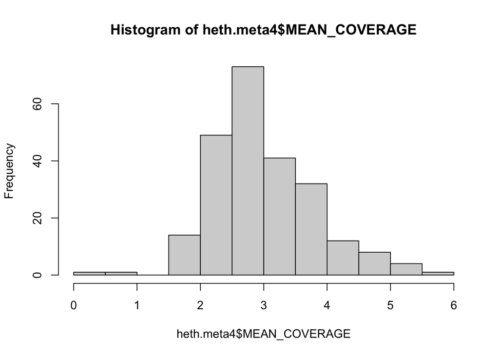

```r
wgs.yr.p <- ggplot(heth.meta4, aes(x= Year, y=MEAN_COVERAGE, color=MEAN_COVERAGE)) +
   geom_point(show.legend = FALSE) +
   scale_color_viridis_c( option = "cividis") +
  theme_minimal()

hist(heth.meta4$MEAN_COVERAGE)
```

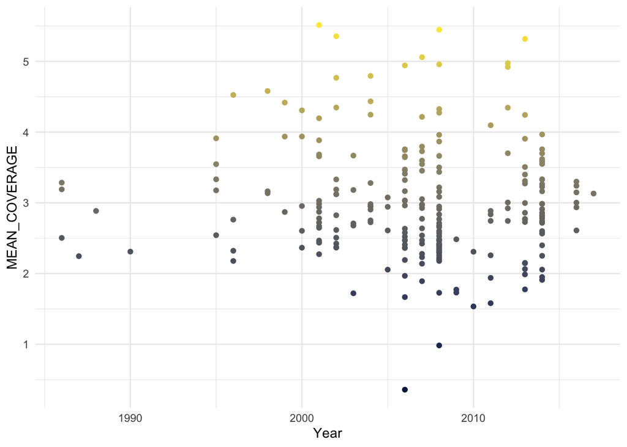

```r
wgs.yr.p
```

Identify low coverage samples

```r
low.cov <- heth.meta4 %>% filter(MEAN_COVERAGE < 2) %>% arrange(MEAN_COVERAGE)

heth.meta4$lowCov <- ifelse(heth.meta4$MEAN_COVERAGE < 2, "low", "no")

low.cov.p <- ggplot(heth.meta4, aes(x=percentMap, y=MEAN_COVERAGE, color=lowCov)) +
  geom_point() +
  scale_color_viridis_d(option = "cividis") +
  theme_minimal()

low.cov.p2 <- ggplot(heth.meta4, aes(x=`Raw reads`, y=MEAN_COVERAGE, color=MEAN_COVERAGE)) +
  geom_point(show.legend = FALSE) +
  scale_color_viridis_c(option = "cividis") +
  theme_minimal()

#low.cov.p
#low.cov.p2

low.cov %>% select(Sample, MEAN_COVERAGE, percentMap, PERCENT_DUPLICATION, Year) %>% arrange(MEAN_COVERAGE)
```

```
## # A tibble: 16 × 5
##    Sample  MEAN_COVERAGE percentMap PERCENT_DUPLICATION  Year
##    <chr>           <dbl>      <dbl>               <dbl> <dbl>
##  1 Z448385         0.358       98.8               0.250  2006
##  2 Z459939         0.984       99.4               0.309  2008
##  3 Z475852         1.53        99.5               0.327  2010
##  4 Z478181         1.58        99.5               0.322  2011
##  5 Z451269         1.67        99.5               0.325  2006
##  6 Z437915         1.72        99.6               0.288  2003
##  7 Z459965         1.73        99.2               0.295  2008
##  8 Z475842         1.73        99.5               0.299  2009
##  9 Z465570         1.77        99.4               0.326  2009
## 10 Z490639         1.78        99.4               0.319  2013
## 11 Z454025         1.89        98.9               0.224  2007
## 12 Z493462         1.91        99.4               0.312  2014
## 13 Z478180         1.94        99.4               0.317  2011
## 14 Z495844         1.95        99.4               0.310  2014
## 15 Z453419         1.97        99.5               0.319  2006
## 16 Z487619         1.99        99.4               0.308  2013
```

Definitely leave out sample Z448385 due to mean cov < 0.5.

# Getting genotype likelihoods for HETH samples

make bamlists

```bash
cd /ocean/projects/deb200006p/adamsne2/HETH/bwa_map/toSWTH

# exclude Z448385 (low cov)
ls *sw.mrkdup.bam | grep -v "Z448385" > HETH.SWTH.235.bamlist

# exclude samples Tiffany ID'd as PCA outliers Z435185, Z438055, Z478178, Z488779, Z495843 from non-SWTH mapped PCA
cat HETH.SWTH.235.bamlist | grep -v -E "Z435185|Z438055|Z478178|Z488779|Z495843" > HETH.SWTH.230.bamlist

# exclude samples missing sex info: Z434750, Z446635, Z451910, Z494099, Z502947, Z504257, Z504258, Z504260, Z505595, Z507123, Z508928
cat HETH.SWTH.230.bamlist | grep -v -E "Z434750|Z446635|Z451910|Z494099|Z502947|Z504257|Z504258|Z504260|Z505595|Z507123|Z508928" > HETH.SWTH.219.bamlist
```

make list of autosomes (remove sex chrs: chr W=CM020377.2/NC_046261.2, chr Z=CM020376.2/NC_046262.2, and mtDNA doesn’t have a NC refSeq number but all scaffolds are “NW”, and maybe “*“)

```bash
# Get list of chr from bam file
samtools idxstats Z507123.sw.mrkdup.bam > HETH_chrListA.txt
cat HETH_chrListA.txt | cut -f 1 > HETH_chrListB.txt
# add : to match region file format for ANGSD
sed 's/$/:/' HETH_chrListB.txt > HETH_chrList.txt

cat HETH_chrList.txt | grep -v "NC_046261.2" | grep -v "NC_046262.2" > HETH_chrList_nosex.txt
cat HETH_chrList_nosex.txt | egrep -v '^NW_*' > HETH_chrList_autos.txt

rm HETH_chrListA.txt
rm HETH_chrListB.txt
```

## Get genotype liklihoods for all samples using ANGSD

(~/scripts/angsd.GL_HETH_SWTH.sbatch)

```bash
#!/bin/bash
#SBATCH --job-name=angsdGL
#SBATCH --output=gl.%j.out
#SBATCH --error=gl.%j.err
#SBATCH -t 48:00:00
#SBATCH -p RM
##SBATCH -N 1
##SBATCH --ntasks-per-node 24
#SBATCH --mem=128G
#SBATCH -A
#SBATCH --mail-type=END
#SBATCH --mail-user=


set -x

BL="HETH.SWTH.219.bamlist"

REFERENCE="/ocean/projects/deb200006p/adamsne2/HETH/reference/GCF_009819885.2_bCatUst1.pri.v2_genomic.fna"
FAI="/ocean/projects/deb200006p/adamsne2/HETH/reference/GCF_009819885.2_bCatUst1.pri.v2_genomic.fna.fai"
OUTDIR="/ocean/projects/deb200006p/adamsne2/HETH/analyses/toSWTH"
outfile=$(echo $BL|sed 's/.bamlist//g')


# beagle for gwas
~/programs/angsd/angsd -bam $BL -P 14 -ref $REFERENCE \
-rf HETH_chrList_nosex.txt \
-trim 0 -uniqueOnly 1 -remove_bads 1 -only_proper_pairs 1 -skipTriallelic 1 \
-minMapQ 20 -minQ 20 \
-minInd 197 -minMaf 0.02 -SNP_pval 2e-6 \
-doHWE 1 -maxHetFreq 0.5 \
-GL 2 -doGlf 2 -doMaf 2 -doMajorMinor 1 -doCounts 1 \
-out "$OUTDIR"/"$outfile"
```

## Get genotype liklihoods for Contemporary samples using ANGSD

(~/scripts/angsd.GL_HETH_SWTH.sbatch)

```bash
#!/bin/bash
#SBATCH --job-name=angsdGL
#SBATCH --output=gl.%j.out
#SBATCH --error=gl.%j.err
#SBATCH -t 48:00:00
#SBATCH -p RM
##SBATCH -N 1
##SBATCH --ntasks-per-node 24
#SBATCH --mem=128G
#SBATCH -A
#SBATCH --mail-type=END
#SBATCH --mail-user=


set -x

# beagle for contemporary 2005+ samples - 10% missing
BL="contemp.2005.bamlist"


REFERENCE="/ocean/projects/deb200006p/adamsne2/HETH/reference/GCF_009819885.2_bCatUst1.pri.v2_genomic.fna"
FAI="/ocean/projects/deb200006p/adamsne2/HETH/reference/GCF_009819885.2_bCatUst1.pri.v2_genomic.fna.fai"
OUTDIR="/ocean/projects/deb200006p/adamsne2/HETH/analyses/toSWTH"
outfile=$(echo $BL|sed 's/.bamlist//g')

~/programs/angsd/angsd -bam $BL -P 128 -ref $REFERENCE \
-rf HETH_chrList_noSex.txt \
-trim 0 -uniqueOnly 1 -remove_bads 1 -only_proper_pairs 1 -skipTriallelic 1 \
-minMapQ 20 -minQ 20 \
-minInd 131 -minMaf 0.02 -SNP_pval 2e-6 \
-doHWE 1 -maxHetFreq 0.5 \
-GL 2 -doGlf 2 -doMaf 2 -doMajorMinor 1 -doCounts 1 \
-out "$OUTDIR"/contemporary/"$outfile"
```

### Swap underscore for hypen in chromosome names

(~/scripts/swapUnforHyph.sbatch)

```bash
#!/bin/bash
#SBATCH --job-name=swap
#SBATCH --output=swap.%j.out
#SBATCH --error=swap.%j.err
#SBATCH -t 2:00:00
#SBATCH -p RM-shared
#SBATCH -N 1
##SBATCH --ntasks-per-node 10
##SBATCH --mem=144G
#SBATCH -A
#SBATCH --mail-type=END
#SBATCH --mail-user=

zcat HETH.SWTH.219.noSex.beagle.gz | sed 's/_/-/' | gzip > HETH.SWTH.219.noSex.noUn.beagle.gz


zcat HETH_contemp.2005.beagle.gz | sed 's/_/-/' | gzip > HETH_contemp.2005.noUn.beagle.gz
```